# Assignment 1 for Reproducible Research!

addcheco

27/04/2020

# Introduction

This assignment took a very long time as it takes a lot of work. I hope you appreciate the work that was put into this document as it was my first time making a markdown file.

This assignment will use activity data from a monitoring device whic hrecorded data every 5 minutes. The data consists of two months (October and November).

# Load the Data

The data was loaded directly from the hyperlink in the code chunk. Dataset was inspected with summary and str function but was not displayed here.

```r
#Load file from url
if(!file.exists("activity.csv")) {
  tempfile <- tempfile()
  download.file("http://d396qusza40orc.cloudfront.net/repdata%2Fdata%2Factivity.zip",destfile = tempfile)
  unzip(tempfile)
  unlink(tempfile)
}

#Load the data and call it dat
dat <- read.csv("activity.csv")
newdat <- aggregate(steps~date, data=dat, FUN=sum, na.rm=TRUE)
#remove NAs so I can take mean and median
```

# What is mean total number of steps taken per day?

## Step 1. Determine Total Steps per Day

Took the sum of all steps per date in the dataset. Named this ‘tab’.

```r
tab <- tapply(dat$steps, dat$date, FUN=sum, na.rm=TRUE)
```

## Step 2. Histogram

Let’s make a histogram to show distribution of data.

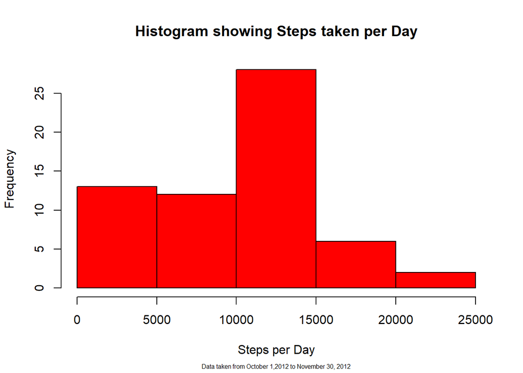

```r
hist(tab,main="Histogram showing Steps taken per Day",sub="Data taken from October 1,2012 to November 30, 2012", xlab="Steps per Day", cex.sub=0.5, col=2)
```

## Step 3. Mean and Median

Mean is 10766.19 Median is 10765

```r
mean_steps <- mean(newdat$steps)
median_steps <- median(newdat$steps)
mean_steps <- format(mean_steps, digits=1)
median_steps <- format(median_steps, digits=1)
```

# What is the average daily activity pattern?

## Step 1. Time Series Plot

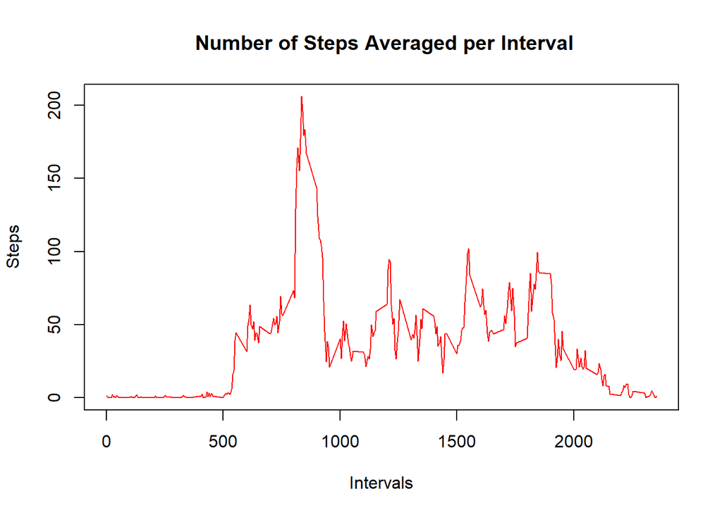

```r
tab2 <- aggregate(steps ~ interval, data = dat, FUN=mean, na.rm=TRUE) #create table of steps mean per interval
plot(tab2$interval,tab2$steps, type= "l", col=2, xlab="Intervals", ylab= "Steps", main= " Number of Steps Averaged per Interval")
```

```r
#time series plot
```

## Step 2. Maximum number?

```r
max(tab2$steps)
```

```
## [1] 206.1698
```

# Imputing missing values

## Step 1.Calculate total number of missing values in the dataset

```r
sum(is.na(dat)) #NA in steps column
```

```
## [1] 2304
```

## Step 2.Devise a strategy for filling in all of the missing values in the dataset

I will just replace with mean.

## Step 3. Create new dataset with the missing data filled in

Seperate the datasets into two sets: with NA and without NA. NAs included will be replaced with mean. Merge the two datasets into a new dataset which has missing data filled in.

```r
AverageStepsInterval <-tapply(dat$steps, dat$interval, mean, na.rm = TRUE)
dat2 <- dat[!is.na(dat$steps),] #data with no NAs
dat3 <- dat[is.na(dat$steps),] #data with NAs
#replace missing values in dat3
dat3$steps <- as.factor(dat3$interval)
  #replace all NA values with the mean
levels(dat3$steps) <- AverageStepsInterval
#but now its a vector... I want integer!
levels(dat3$steps) <- round(as.numeric(levels(dat3$steps)))
dat3$steps <- as.integer(as.vector(dat3$steps))
#Now merge the two datasets of Na or no NA together
TogetherAgain <- rbind(dat3, dat2)
```

## Step 4. Histogram comparing the two datasets

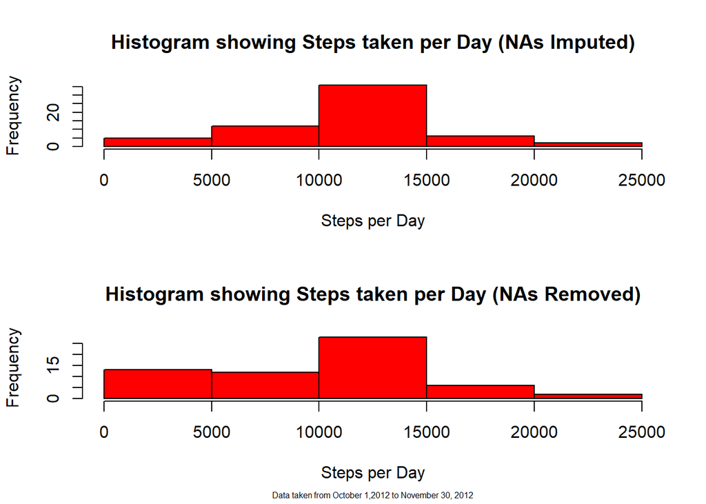

```r
par(mfrow = c(2,1)) #create figure with two plots side by side
dat4 <- aggregate(steps ~ date, data = TogetherAgain, FUN = sum, na.rm = TRUE) #set up data for histogram
hist(dat4$steps, xlab = "Steps per Day", main = "Histogram showing Steps taken per Day (NAs Imputed)", col = 2)
hist(tab,main="Histogram showing Steps taken per Day (NAs Removed)",sub="Data taken from October 1,2012 to November 30, 2012", xlab="Steps per Day", cex.sub=0.5, col=2)
```

The mean and median differ slightly. The new mean with NAs replaced is 10765.64 while the median is 10762.

```r
mean(dat4$steps)
```

```
## [1] 10765.64
```

```r
median(dat4$steps)
```

```
## [1] 10762
```

```r
mean(tab)
```

```
## [1] 9354.23
```

```r
median(tab)
```

```
## [1] 10395
```

# Are there differences in activity patterns between weekdays and weekends?

## Step 1. Creating a new variable describing if it is a weekday or weekend

```r
library(dplyr)
library(lubridate)
TogetherAgain['weektype'] = transmute(TogetherAgain, weektype = ifelse(wday(TogetherAgain$date, label=TRUE)=="Sat"| wday(TogetherAgain$date, label=TRUE)=="Sun", "weekend", "weekday"))
TogetherAgain$weektype <- as.factor(TogetherAgain$weektype)
head(TogetherAgain)
```

```
##   steps       date interval weektype
## 1     2 2012-10-01        0  weekday
## 2     0 2012-10-01        5  weekday
## 3     0 2012-10-01       10  weekday
## 4     0 2012-10-01       15  weekday
## 5     0 2012-10-01       20  weekday
## 6     2 2012-10-01       25  weekday
```

## Step 2.Time series plot

```r
#Time to make table with averages
steps_interval_dayType <- aggregate(steps~interval + weektype, data= TogetherAgain, FUN=mean)
head(steps_interval_dayType) # wow interesting table!
```

```
##   interval weektype      steps
## 1        0  weekday 2.28888889
## 2        5  weekday 0.40000000
## 3       10  weekday 0.15555556
## 4       15  weekday 0.17777778
## 5       20  weekday 0.08888889
## 6       25  weekday 1.57777778
```

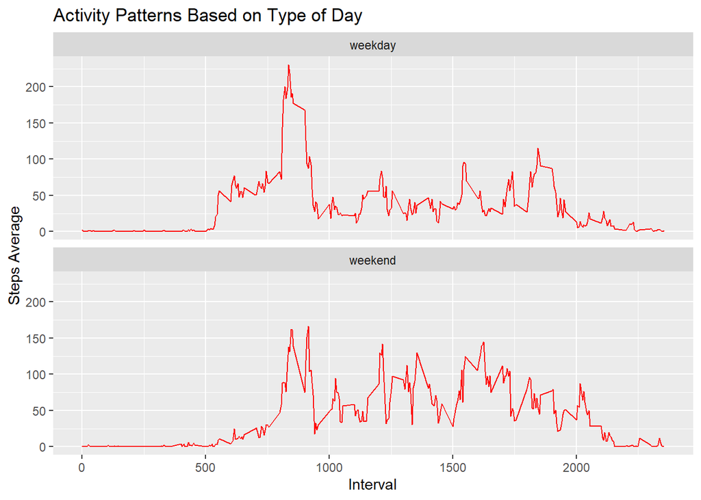

```r
#Let's make a beautiful ggplot because ggplot is beautiful
library(ggplot2)
names(steps_interval_dayType) <- c("interval", "day_type", "mean_steps")
plot<- ggplot(steps_interval_dayType, aes(interval, mean_steps, color=day_type))
plot+geom_line(colour=2) + facet_wrap(~day_type, nrow=2, ncol=1)+ labs(y="Steps Average", x="Interval", title="Activity Patterns Based on Type of Day")
```

Conclusions: After hours of figuring out where my weekend data went, I finally found it. This allowed me to make the concluson that weekends appear to have a later start (the person probably sleeps in). The person also has a spike of steps during the weekdays which is not seen on the weekend which could signify when they go to the gym.